# Haul Size Effect

Brett Stacy

2024-06-19

## What is the impact of scaling by haul size?

Haul size ranges a lot for EBS Pcod. We sample ~20 fish on every haul but only the samples from the larger hauls have a significant impact on the population proportions at length if we use haul size as an importance scaler.

load pcod data

illustrate range of haul sizes. plot probability haul sizes by groups (reasonable size classes).

Show that if we scale by haul size, how many samples have a miniscule impact on the length distribution

i.e., for hauls size max with 1% or less impact on length distribution, what is the percent samples in these hauls?

Load in pcod data

### Full data set

Plot histogram of haul size in numbers of fish

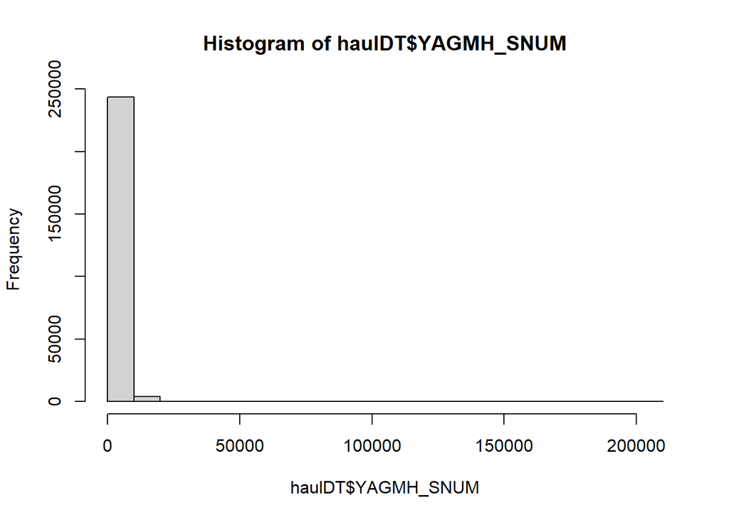

```
##    Min. 1st Qu.  Median    Mean 3rd Qu.    Max.
##       1    1053    1893    2565    3238  202927
```

Sort the hauls by size, then find the haul that represents 1% of the total catch threshold

“the smallest 1% of hauls contain X% of length data”

```
## [1] 20077
```

```
## [1] 0.000717658
```

```
## [1] 0.0740412
```

Do it another way. This should be equivalent. Calculate the percentage of SNUM to the sum of SNUM, then scale it by the highest SNUM percentage (last in ordered DT)

```
## [1] 132283
```

```
## [1] 0.5053178
```

Uh-oh. This gives a different answer. And I don’t know which one (if any) are correct.

### One year of data

Now for one year, say 2022, find out how many times more influence 20 samples from a big haul have compared to 20 samples from a small haul. Perhaps use the 25% biggest haul and the 75% biggest haul. Is this the right way to do this? Just calculate the proportion of influence of each haul first maybe. then order them, or order them prior doesn’t matter, then check the proportion of influence of the 25% largest haul and compare it to the 75% largest haul. Compare them by dividing their proportions.

#### Same analysis as above:

```
## [1] 0.05817948
```